# Covid in HH

John-Philipp Vogt

# 0 Packages and Scripts

Script runs: Load tidyverse, load `RKI_imptran`, `RKI_geofil`.

```r
library(tidyverse)

RKI_imptran <- function(x){
  read_csv(x, col_types = list(
    Altersgruppe = col_factor(),
    Geschlecht = col_factor(),
    IstErkrankungsbeginn = col_logical()
  )) %>%
    rename(geo_ID = IdLandkreis,age_group = Altersgruppe,
           sex = Geschlecht, rep_date = Meldedatum,
           ref_date = Refdatum, ref_rep_date = IstErkrankungsbeginn,
           amount_case = AnzahlFall, amount_death = AnzahlTodesfall,
           amount_recovery = AnzahlGenesen, new_case = NeuerFall,
           new_death = NeuerTodesfall, new_recovery = NeuGenesen)
}

RKI_geofil <- function(x, y){
  x %>% filter(geo_ID == y)
}
```

# 1 Introducing data to R

Scripts runs: Load current `.csv`, run `RKI_imptran` and `RKI_geofil`.

```r
inf_FRG <- RKI_imptran("/home/jpv/Documents/Uni/D.Proc.Vis/rStudioWD/covid_frg_project/SARS-CoV-2_Infektionen_in_Deutschland/Aktuell_Deutschland_SarsCov2_Infektionen.csv")

inf_HH <- RKI_geofil(inf_FRG, 2000)
```

```r
inf_FRG_new_cases <- RKI_imptran("/home/jpv/Documents/Uni/D.Proc.Vis/rStudioWD/covid_frg_project/SARS-CoV-2_Infektionen_in_Deutschland/Archiv/all_new_cases.csv")
```

After, to filter for desired geo-location, run:

```r
inf_HH_new_cases <- RKI_geofil(inf_FRG_new_cases, 2000)
```

Remark: The following are computed for Hamburg only.

# 2 Rebuilding metrics

Following metrics are rebuilt:

1. Cumulative cases, deaths, and recoveries up to now
2. New cases, deaths, and recoveries each day

## Active cases currently, and per day since start of recorded case

## 2.1 Cumulative Cases, Deaths, and Recoveries

### 2.1.1 Cumulative Total of Confirmed Cases

```r
inf_HH %>%
  transmute(total_of_confirmed_cases = cumsum(amount_case)) %>%
  slice_tail()
```

| total_of_confirmed_cases |
| --- |
| 551346 |

#### Sorted by Age Bracket descending

```r
inf_HH %>%
  group_by(age_group) %>%
  transmute(total_of_confirmed_cases = cumsum(amount_case)) %>%
  slice_tail() %>%
  arrange(desc(total_of_confirmed_cases))
```

| age_group | total_of_confirmed_cases |
| --- | --- |
| A35-A59 | 194771 |
| A15-A34 | 191744 |
| A05-A14 | 85273 |
| A60-A79 | 43294 |
| A00-A04 | 21255 |
| A80+ | 14813 |
| unbekannt | 196 |

#### Sorted by Sex

```r
inf_HH %>%
  group_by(sex) %>%
  transmute(total_of_confirmed_cases = cumsum(amount_case)) %>%
  slice_tail() %>%
  arrange(desc(total_of_confirmed_cases))
```

| sex | total_of_confirmed_cases |
| --- | --- |
| W | 282714 |
| M | 265361 |
| unbekannt | 3271 |

### 2.1.2 Cumulative Total of Confirmed Cases (Visualised)

By `ref_date`:

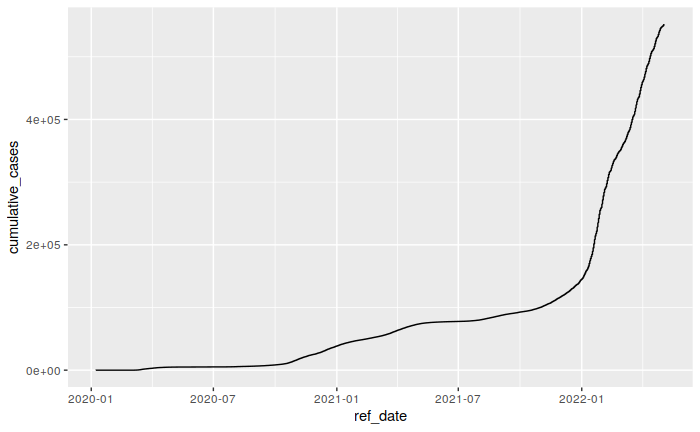

```r
inf_HH %>% select(ref_date, amount_case) %>%
  arrange(ref_date) %>%
  mutate(cumulative_cases = cumsum(amount_case)) %>%
  ggplot(aes(x = ref_date, y = cumulative_cases)) + geom_line()
```

By `rep_date`:

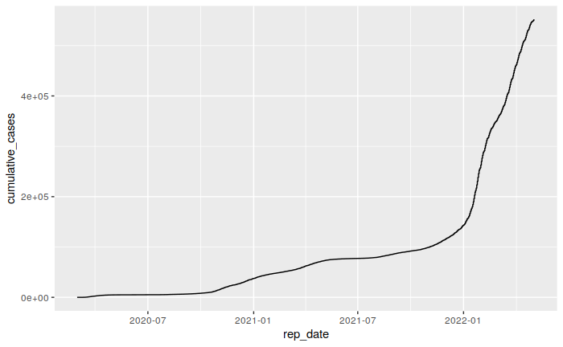

```r
inf_HH %>% select(rep_date, amount_case) %>%
  arrange(rep_date) %>%
  mutate(cumulative_cases = cumsum(amount_case)) %>%
  ggplot(aes(x = rep_date, y = cumulative_cases)) + geom_line()
```

### 2.1.3 Cumulative Total of Confirmed Deaths

```r
inf_HH %>%
  transmute(total_of_confirmed_deaths = cumsum(amount_death)) %>%
  slice_tail()
```

| total_of_confirmed_deaths |
| --- |
| 2556 |

#### Sorted By Age Group Descending

```r
inf_HH %>%
  group_by(age_group) %>%
  transmute(total_of_confirmed_deaths = cumsum(amount_death)) %>%
  slice_tail() %>%
  arrange(desc(total_of_confirmed_deaths))
```

| age_group | total_of_confirmed_deaths |
| --- | --- |
| A80+ | 1565 |
| A60-A79 | 802 |
| A35-A59 | 169 |
| A15-A34 | 17 |
| A00-A04 | 2 |
| A05-A14 | 1 |
| unbekannt | 0 |

#### Sorted by Sex

```r
inf_HH %>%
  group_by(sex) %>%
  transmute(total_of_confirmed_deaths = cumsum(amount_death)) %>%
  slice_tail() %>%
  arrange(desc(total_of_confirmed_deaths))
```

| sex | total_of_confirmed_deaths |
| --- | --- |
| M | 1402 |
| W | 1154 |
| unbekannt | 0 |

### 2.1.4 Cumulative Total of Confirmed Deaths (Visualised)

by `ref_date`:

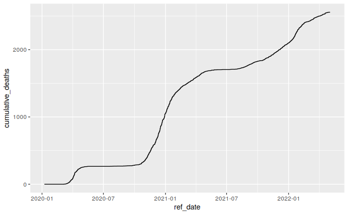

```r
inf_HH %>% select(ref_date, amount_death) %>%
  arrange(ref_date) %>%
  mutate(cumulative_deaths = cumsum(amount_death)) %>%
  ggplot(aes(x = ref_date, y = cumulative_deaths)) + geom_line()
```

by `rep_date`:

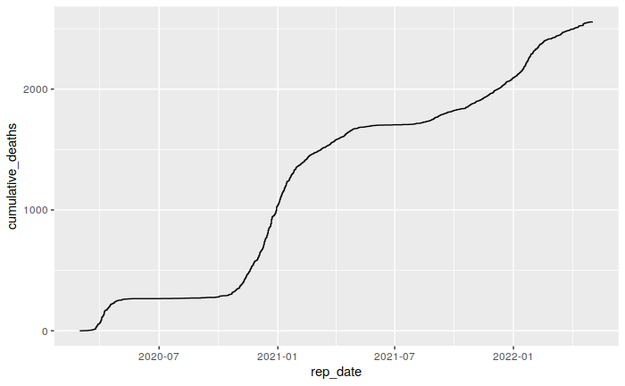

```r
inf_HH %>% select(rep_date, amount_death) %>%
  arrange(rep_date) %>%
  mutate(cumulative_deaths = cumsum(amount_death)) %>%
  ggplot(aes(x = rep_date, y = cumulative_deaths)) + geom_line()
```

### 2.1.5 Cumulative Total of Confirmed Recoveries

```r
inf_HH %>%
  transmute(total_of_confirmed_recoveries = cumsum(amount_recovery)) %>%
  slice_tail()
```

[output not shown]

#### Sorted by Age Group Descending

```r
inf_HH %>%
  group_by(age_group) %>%
  transmute(total_of_confirmed_recoveries = cumsum(amount_recovery)) %>%
  slice_tail() %>%
  arrange(desc(total_of_confirmed_recoveries))
```

[output not shown]

#### Sorted by Sex

```r
inf_HH %>%
  group_by(sex) %>%
  transmute(total_of_confirmed_recoveries = cumsum(amount_recovery)) %>%
  slice_tail() %>%
  arrange(desc(total_of_confirmed_recoveries))
```

[output not shown]

### 2.1.6 Cumulative Total of Confirmed Recoveries (Visualised)

by `ref_date`:

```r
inf_HH %>% select(ref_date, amount_recovery) %>%
  arrange(ref_date) %>%
  mutate(cumulative_recoveries = cumsum(amount_recovery)) %>%
  ggplot(aes(x = ref_date, y = cumulative_recoveries)) + geom_line()
```

[output not shown]

by `rep_date`:

```r
inf_HH %>% select(rep_date, amount_recovery) %>%
  arrange(rep_date) %>%
  mutate(cumulative_recoveries = cumsum(amount_recovery)) %>%
  ggplot(aes(x = rep_date, y = cumulative_recoveries)) + geom_line()
```

[output not shown]

## 2.2 New Cases, Deaths, and Recoveries

### 2.2.1 Currently New Cases

This script shows the latest “new” cases as published by the RKI, which means these are those cases, which have been reported to the RKI on the previous day. Meaning they are not the most current, but those which are “officially” declared (i.e. published) by the RKI. By `ref_date`:

```r
inf_HH %>% select(ref_date, new_case, starts_with("amount")) %>%
  filter(new_case != 0 & amount_death == 0 & amount_recovery == 0) %>%
  select(ref_date, amount_case) %>%
  group_by(ref_date) %>%
  summarise(amount_case = sum(amount_case)) %>% arrange(desc(ref_date))
```

| ref_date | amount_case |
| --- | --- |
| 2022-05-05 | 81 |
| 2022-05-04 | 1485 |
| 2022-05-03 | 612 |
| 2022-05-02 | 390 |
| 2022-05-01 | 155 |
| 2022-04-30 | 224 |
| 2022-04-29 | 250 |
| 2022-04-28 | 42 |
| 2022-04-27 | 23 |
| 2022-04-26 | 20 |

[output cut: 9 more lines]

By `rep_date`:

```r
inf_HH %>% select(rep_date, new_case, starts_with("amount")) %>%
  filter(new_case != 0 & amount_death == 0 & amount_recovery == 0) %>%
  select(rep_date, ends_with("case"))%>%
  group_by(rep_date) %>%
  summarise(amount_case = sum(amount_case)) %>%
arrange(desc(rep_date))
```

### 2.2.2 Daily New Cases (Visualised)

by `ref_date`:

```r
inf_HH_new_cases %>% select(ref_date, starts_with("amount")) %>%
  filter(amount_death == 0 & amount_recovery == 0) %>%
  select(ref_date, amount_case) %>%
  group_by(ref_date) %>%
  summarise(amount_case = sum(amount_case)) %>%
  arrange(desc(ref_date)) %>%
  ggplot(aes(x = ref_date, y = amount_case)) + geom_line()
```

by `rep_date`:

```r
inf_HH_new_cases %>% select(rep_date, starts_with("amount")) %>%
  filter(amount_death == 0 & amount_recovery == 0) %>%
  select(rep_date, amount_case) %>%
  group_by(rep_date) %>%
  summarise(amount_case = sum(amount_case)) %>%
  arrange(desc(rep_date)) %>%
  ggplot(aes(x = rep_date, y = amount_case)) + geom_line()
```

### 2.2.2 Currently New Deaths

by `ref_date`:

```r
inf_HH %>% select(ref_date, new_case, amount_death) %>%
  filter(new_case != 0) %>%
  select(ref_date, amount_death) %>%
  group_by(ref_date) %>%
  summarise(amount_death = sum(amount_death)) %>%
  arrange(desc(ref_date))
```

by `rep_date`:

```r
inf_HH %>% select(rep_date, new_case, amount_death) %>%
  filter(new_case != 0) %>%
  select(rep_date, amount_death) %>%
  group_by(rep_date) %>%
  summarise(amount_death = sum(amount_death)) %>%
  arrange(desc(rep_date))
```

### 2.2.3 Daily New Deaths

by `ref_date`:

```r
inf_HH_new_cases %>% select(ref_date, amount_death) %>%
  filter(amount_death != 0) %>%
  group_by(ref_date) %>%
  summarise(amount_death = sum(amount_death)) %>%
  arrange(desc(ref_date)) %>%
  ggplot(aes(x = ref_date, y = amount_death)) + geom_line()
```

by `rep_date`:

```r
inf_HH_new_cases %>% select(rep_date, amount_death) %>%
  filter(amount_death != 0) %>%
  group_by(rep_date) %>%
  summarise(amount_death = sum(amount_death)) %>%
  arrange(desc(rep_date)) %>%
  ggplot(aes(x = rep_date, y = amount_death)) + geom_line()
```

### 2.2.3 Currently New Recoveries

by `ref_date`:

```r
inf_HH %>% select(ref_date, new_case, amount_recovery) %>%
  filter(new_case != 0) %>%
  select(ref_date, amount_recovery) %>%
  group_by(ref_date) %>%
  summarise(amount_recovery = sum(amount_recovery)) %>%
  arrange(desc(ref_date))
```

by `rep_date`:

```r
inf_HH %>% select(rep_date, new_case, amount_recovery) %>%
  filter(new_case != 0) %>%
  select(rep_date, amount_recovery) %>%
  group_by(rep_date) %>%
  summarise(amount_recovery = sum(amount_recovery)) %>%
  arrange(desc(rep_date))
```

### 2.2.4 Daily New Recoveries

by `ref_date`:

```r
inf_HH_new_cases %>% select(ref_date, amount_recovery) %>%
  filter(amount_recovery != 0) %>%
  group_by(ref_date) %>%
  summarise(amount_recovery = sum(amount_recovery)) %>%
  arrange(desc(ref_date)) %>%
  ggplot(aes(x = ref_date, y = amount_recovery)) + geom_line()
```

by `rep_date`:

```r
inf_HH_new_cases %>% select(rep_date, amount_recovery) %>%
  filter(amount_recovery != 0) %>%
  group_by(rep_date) %>%
  summarise(amount_recovery = sum(amount_recovery)) %>%
  arrange(desc(rep_date)) %>%
  ggplot(aes(x = rep_date, y = amount_recovery)) + geom_line()
```

## 2.3 Active Cases

by `ref_date`:

```r
inf_HH %>% select(ref_date, new_case, starts_with("amount")) %>%
  arrange(ref_date) %>%
  mutate(cumulative_cases = cumsum(amount_case)) %>%
  mutate(cumulative_deaths = cumsum(amount_death)) %>%
  mutate(cumulative_recoveries = cumsum(amount_recovery)) %>%
  mutate(delta = cumulative_cases - (cumulative_deaths + cumulative_recoveries)) %>%
  select(ref_date, starts_with("c"), delta) %>%
  slice_tail()
```

[output not shown]

by `rep_date`:

```r
inf_HH %>% select(rep_date, new_case, starts_with("amount")) %>%
  arrange(rep_date) %>%
  mutate(cumulative_cases = cumsum(amount_case)) %>%
  mutate(cumulative_deaths = cumsum(amount_death)) %>%
  mutate(cumulative_recoveries = cumsum(amount_recovery)) %>%
  mutate(delta = cumulative_cases - (cumulative_deaths + cumulative_recoveries)) %>%
  select(rep_date, starts_with("c"), delta) %>%
  slice_tail()
```

[output not shown]